# Neo4j

```python
%load_ext cypher
```

```python
from py2neo import Graph, Node, Relationship

graph = Graph()
```

```python
# Borrado de todos los nodos y relaciones
graph.delete_all()
```

## Carga de datos en Pandas

A partir del fichero Excel desnormalizamos los datos

```python
import pandas as pd
df_mov = pd.read_excel("./data/black.xlsx", sheet_name= "Movimientos", engine='openpyxl')
df_miembros = pd.read_excel("./data/black.xlsx", sheet_name= "Miembros", engine='openpyxl')
df = pd.merge(df_mov, df_miembros, on = ['id_miembro'], how = 'inner')
df.info()
```

```
<class 'pandas.core.frame.DataFrame'>
Int64Index: 7624 entries, 0 to 7623
Data columns (total 11 columns):
 #   Column              Non-Null Count  Dtype
---  ------              --------------  -----
 0   id_miembro          7624 non-null   int64
 1   fecha               7624 non-null   datetime64[ns]
 2   hora                7624 non-null   int64
 3   minuto              7624 non-null   int64
 4   importe             7624 non-null   float64
 5   comercio            6882 non-null   object
 6   actividad_completa  7621 non-null   object
 7   actividad           7621 non-null   object
 8   nombre              7624 non-null   object
 9   funcion             7624 non-null   object
 10  organizacion        6060 non-null   object
dtypes: datetime64[ns](1), float64(1), int64(3), object(6)
memory usage: 714.8+ KB
```

## Carga de datos en Neo4j

Limpiamos los datos para que no tengan nulos y evitar problemas con la sentencia MERGE de Neo

```python
df.loc[df.comercio.isnull(),['comercio']] = 'Desconocido'
df.loc[df.organizacion.isnull(),['organizacion']] = 'Desconocido'
df.loc[df.actividad.isnull(),['actividad']] = 'Desconocido'
df.loc[df.actividad_completa.isnull(),['actividad_completa']] = 'Desconocido'
```

La carga se realizará en Neo a partir de la lista de datos en formato JSON, generados con Pandas

```python
import json

json_string = df.to_json(orient = 'records')
json_list = json.loads(json_string)
```

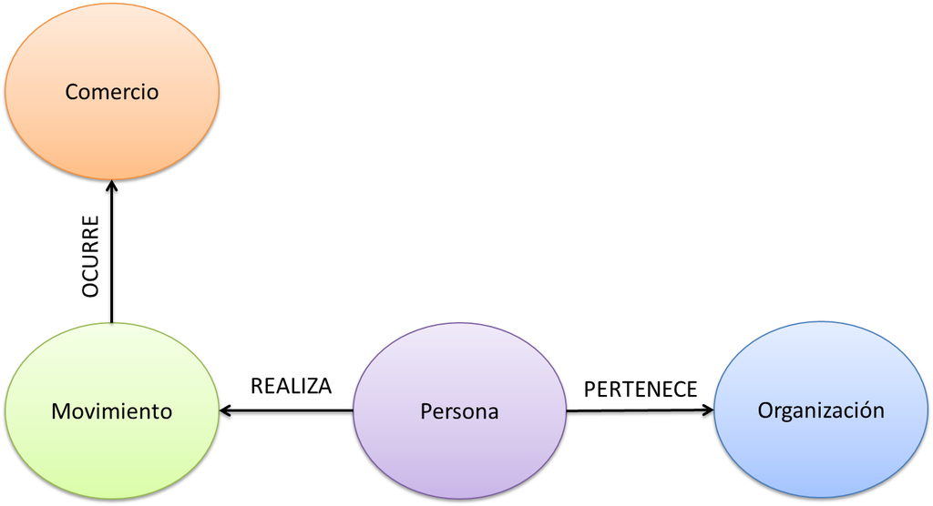

Adicionalmente se van a guardar los siguientes atributos:

**Nodo Comercio**

- Nombre del comercio
- Actividad a la que se dedica
- Categoría de actividad (Podríamos haber creado un tipo de nodo independente)

**Nodo Persona**

- Nombre de la persona

**Nodo Organización**

- Nombre de la organización

**Nodo Movimiento**

- Fecha en formato UNIX Timestamp (el mismo formato que está en el JSON)
- hora y minuto de la compra
- Importe de la compra

Respecto a las relaciones, vamos a almacenar los siguientes atributos:

**Relación PERTECENE**

- Función que hace la persona en una organización

Creamos los nodos y relaciones en Neo4j simplemente iterando sobre la lista de JSONs.

```python
import datetime

for index, movimiento_json in enumerate(json_list):
    # Nodos
    persona = Node("Persona", nombre=movimiento_json["nombre"])
    comercio = Node("Comercio", nombre=movimiento_json["comercio"],
                                actividad = movimiento_json["actividad"],
                                actividad_completa = movimiento_json["actividad_completa"])
    organizacion = Node("Organizacion", nombre = movimiento_json["organizacion"])
    movimiento = Node("Movimiento",
            fecha = movimiento_json['fecha'],
            hora =  movimiento_json["hora"],
            minuto =  movimiento_json["minuto"],
            importe = movimiento_json["importe"])


    # Relaciones
    rel_persona_organizacion = Relationship(persona, "PERTENECE", organizacion,
                                           funcion = movimiento_json["funcion"])
    rel_persona_movimiento = Relationship(persona, "REALIZA", movimiento)
    rel_movimiento_comercio = Relationship(movimiento, "OCURRE", comercio)

    graph.merge(persona, "Persona", "nombre")
    graph.merge(comercio, "Comercio", "nombre")
    graph.merge(organizacion, "Organizacion", "nombre")
    graph.merge(rel_persona_organizacion)
    graph.create(movimiento | rel_persona_movimiento | rel_movimiento_comercio)

    if index % 500 == 0:
        print(index)
```

```
0
500
1000
1500
2000
2500
3000
3500
4000
4500
5000
5500
6000
6500
7000
7500
```

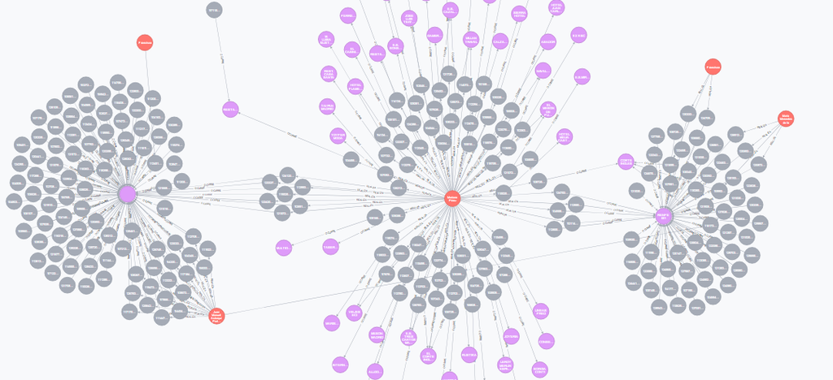

### Comprobaciones previas ...

Número de movimientos ...

```python
%%cypher
MATCH (:Movimiento)
RETURN count(*)
```

```
1 rows affected.
```

| count(*) |
| --- |
| 7624 |

Número de personas ...

```python
%%cypher
MATCH (:Persona)
RETURN count(*)
```

```
1 rows affected.
```

| count(*) |
| --- |
| 82 |

Número de comercios

```python
%%cypher
MATCH (c:Comercio)
WHERE c.nombre <> 'Desconocido'
RETURN count(*)
```

```
1 rows affected.
```

| count(*) |
| --- |
| 3051 |

Número de organizaciones

```python
%%cypher
MATCH (o:Organizacion)
WHERE o.nombre <> 'Desconocido'
RETURN count(*)
```

```
1 rows affected.
```

| count(*) |
| --- |
| 10 |

All good!

## Funciones de utilidad para la consulta de datos

Neo4j, en su versión actual, no puede guardar datos de tipo fecha en los atributos, por lo que se almacena en formato TIMESTAMP de Unix (el formato original).

La siguiente función de utilidad convierte una columna de una DataFrame en formato TIMESTAMP a Fecha

```python
def transform_date(df, column_name):
    if column_name in df.columns:
        # Las fechas están en formato UNIX TIMESTAMP. Las volvemos a convertir a formato Date...
        df[column_name] = pd.to_datetime(df[column_name], unit = 'ms')

    return df
```

Función de utilidad para convertir los resultados devueltos por la base de datos en un DataFrame de Pandas

```python
def get_dataframe(data):
    df = pd.DataFrame(list(data), columns = data.keys())

    return df
```

## Consulta a Neo4j

### Los 10 movimientos mas caros

```python
%%cypher
MATCH (persona:Persona)-[:REALIZA]-(movimiento:Movimiento)-[:OCURRE]-(comercio:Comercio)
RETURN persona.nombre, comercio.actividad_completa, movimiento.importe
ORDER BY movimiento.importe DESC
LIMIT 10
```

```
10 rows affected.
```

| persona.nombre | comercio.actividad_completa | movimiento.importe |
| --- | --- | --- |
| Enrique de la Torre Martínez | INSTRUMENTOS MUSICALES | 12000.0 |
| Ramón Ferraz Ricarte | INSTRUMENTOS MUSICALES | 9424.08 |
| Enrique de la Torre Martínez | INSTRUMENTOS MUSICALES | 9000.0 |
| Enrique de la Torre Martínez | INSTRUMENTOS MUSICALES | 8000.0 |
| Miguel Blesa de la Parra | EL CORTE INGLES | 6397.31 |
| Rafael Spottorno Díaz Caro | CONFECCION TEXTIL EN GENERAL | 6375.0 |
| Carmen Contreras Gómez | HOTELES 4 Y 5 ESTRELLAS,BALNEARIOS,CAMPI | 6198.02 |
| Matías Amat Roca | INSTRUMENTOS MUSICALES | 5763.1 |
| Juan Manuel Astorqui Portera | AUTOM.Y MOTOCICLETAS ( VENTAS Y REPARAC) | 5403.97 |
| Enrique de la Torre Martínez | INSTRUMENTOS MUSICALES | 5390.0 |

Utilizamos la función ** graph.run()** para obtener un ResultSet de datos, que es transformada en un Dataframe de Pandas

```python
query = """
MATCH (persona:Persona)-[:REALIZA]-(movimiento:Movimiento)-[:OCURRE]-(comercio:Comercio)
RETURN persona.nombre, comercio.actividad_completa, movimiento.importe
ORDER BY movimiento.importe DESC
LIMIT 10
"""

data = graph.run(query)
df = get_dataframe(data)
df = transform_date(df, 'compra.fecha')
df
```

|  | persona.nombre | comercio.actividad_completa | movimiento.importe |
| --- | --- | --- | --- |
| 0 | Enrique de la Torre Martínez | INSTRUMENTOS MUSICALES | 12000.00 |
| 1 | Ramón Ferraz Ricarte | INSTRUMENTOS MUSICALES | 9424.08 |
| 2 | Enrique de la Torre Martínez | INSTRUMENTOS MUSICALES | 9000.00 |
| 3 | Enrique de la Torre Martínez | INSTRUMENTOS MUSICALES | 8000.00 |
| 4 | Miguel Blesa de la Parra | EL CORTE INGLES | 6397.31 |
| 5 | Rafael Spottorno Díaz Caro | CONFECCION TEXTIL EN GENERAL | 6375.00 |
| 6 | Carmen Contreras Gómez | HOTELES 4 Y 5 ESTRELLAS,BALNEARIOS,CAMPI | 6198.02 |
| 7 | Matías Amat Roca | INSTRUMENTOS MUSICALES | 5763.10 |
| 8 | Juan Manuel Astorqui Portera | AUTOM.Y MOTOCICLETAS ( VENTAS Y REPARAC) | 5403.97 |
| 9 | Enrique de la Torre Martínez | INSTRUMENTOS MUSICALES | 5390.00 |

La misma query que el caso anterior pero utilizando un método distinto.  
El fin es el mismo: Una DataFrame de Pandas

```python
df = %cypher MATCH (persona:Persona)-[:REALIZA]-(movimiento:Movimiento)-[:OCURRE]-(comercio:Comercio) \
             RETURN persona.nombre, comercio.actividad_completa, movimiento.importe \
             ORDER BY movimiento.importe DESC \
             LIMIT 10

df.get_dataframe()
```

```
10 rows affected.
```

|  | persona.nombre | comercio.actividad_completa | movimiento.importe |
| --- | --- | --- | --- |
| 0 | Enrique de la Torre Martínez | INSTRUMENTOS MUSICALES | 12000.00 |
| 1 | Ramón Ferraz Ricarte | INSTRUMENTOS MUSICALES | 9424.08 |
| 2 | Enrique de la Torre Martínez | INSTRUMENTOS MUSICALES | 9000.00 |
| 3 | Enrique de la Torre Martínez | INSTRUMENTOS MUSICALES | 8000.00 |
| 4 | Miguel Blesa de la Parra | EL CORTE INGLES | 6397.31 |
| 5 | Rafael Spottorno Díaz Caro | CONFECCION TEXTIL EN GENERAL | 6375.00 |
| 6 | Carmen Contreras Gómez | HOTELES 4 Y 5 ESTRELLAS,BALNEARIOS,CAMPI | 6198.02 |
| 7 | Matías Amat Roca | INSTRUMENTOS MUSICALES | 5763.10 |
| 8 | Juan Manuel Astorqui Portera | AUTOM.Y MOTOCICLETAS ( VENTAS Y REPARAC) | 5403.97 |
| 9 | Enrique de la Torre Martínez | INSTRUMENTOS MUSICALES | 5390.00 |

### Importes de una persona agrupados por actividad

En este caso se realiza una agrupación de los datos. Observa que Neo4j lo realiza automáticamente al utilizar una función de agrupación de datos como **SUM()**

```python
%%cypher
MATCH (persona:Persona)-[:REALIZA]-(movimiento:Movimiento)-[:OCURRE]-(comercio:Comercio)
WHERE comercio.actividad = 'HOGAR'
RETURN persona.nombre, comercio.actividad_completa, SUM(movimiento.importe) as importe
ORDER BY importe DESC
LIMIT 10
```

```
10 rows affected.
```

| persona.nombre | comercio.actividad_completa | importe |
| --- | --- | --- |
| Francisco Baquero Noriega | MUEBLES,ANTIGUEDADES Y GALERIAS DE ARTE | 3024.5 |
| Pedro Bugidos Garay | MUEBLES,ANTIGUEDADES Y GALERIAS DE ARTE | 2921.0 |
| Mariano Pérez Claver | FLORES Y PLANTAS | 2858.59 |
| Miguel Ángel Araujo Serrano | MUEBLES,ANTIGUEDADES Y GALERIAS DE ARTE | 2150.0 |
| Domingo Navalmoral Sánchez | TAPICERIAS,ALFOMBRAS | 1800.0 |
| Miguel Ángel Araujo Serrano | MUEBLES DE COCINA | 1231.0 |
| Jesús Pedroche Nieto | MUEBLES,ANTIGUEDADES Y GALERIAS DE ARTE | 1213.33 |
| Ricardo Romero de Tejada y Picatoste | ELECTRODOMESTICOS,EQUIPOS ELECTRICOS | 1000.0 |
| María Carmen Cafranga Cavestany | MUEBLES,ANTIGUEDADES Y GALERIAS DE ARTE | 850.0 |
| Alejandro Couceiro Ojeda | ELECTRODOMESTICOS,EQUIPOS ELECTRICOS | 776.07 |

```python
query = """
MATCH (organizacion:Organizacion)-[:PERTENECE]-(persona:Persona)-[:REALIZA]-(movimiento:Movimiento)-[:OCURRE]-(comercio:Comercio)
WHERE persona.nombre = {name}
RETURN persona.nombre, comercio.actividad, SUM(movimiento.importe) as importe
ORDER BY importe DESC
"""

data = graph.run(query, name='Mariano Pérez Claver')
get_dataframe(data)
```

|  | persona.nombre | comercio.actividad | importe |
| --- | --- | --- | --- |
| 0 | Mariano Pérez Claver | COMPRA BIENES | 9146.54 |
| 1 | Mariano Pérez Claver | HOGAR | 3633.59 |
| 2 | Mariano Pérez Claver | RESTAURANTE | 3517.73 |
| 3 | Mariano Pérez Claver | VIAJE | 3013.95 |
| 4 | Mariano Pérez Claver | SALUD | 1863.00 |
| 5 | Mariano Pérez Claver | HOTEL | 1274.75 |
| 6 | Mariano Pérez Claver | COCHE | 1056.19 |
| 7 | Mariano Pérez Claver | ROPA | 1011.90 |
| 8 | Mariano Pérez Claver | REGALOS | 850.00 |
| 9 | Mariano Pérez Claver | AVION | 285.23 |
| 10 | Mariano Pérez Claver | MISC | 137.04 |
| 11 | Mariano Pérez Claver | IMAGEN | 136.94 |
| 12 | Mariano Pérez Claver | SUPERMERCADO | 71.59 |
| 13 | Mariano Pérez Claver | TREN | 66.59 |
| 14 | Mariano Pérez Claver | DUTYFREE | 62.50 |